# Session 3 — Multiple Imputation with mice

Chained equations · pmm · m imputations · convergence · checking · pooling with Rubin’s rules · Lab 3

Community Medicine Workshop

## Where we are

- Session 2: simple methods are biased or have wrong SEs
- Today: **multiple imputation (MI)** with the **`mice`** package
- By the end you can:
  - run `mice()` and read its **methods and predictor matrix**
  - **check** convergence and imputed values
  - **analyse** each data set and **pool** with Rubin’s rules

# Topic 1 — The idea

## Three steps

**Impute** (m times) → **Analyse** (each data set) → **Pool** (Rubin’s rules)

1. Create **m complete data sets**; the imputed values **differ** between them, reflecting **uncertainty**
2. Run the **same analysis** in each (`with()`)
3. **Pool**: the estimate is the **average**; the variance combines **within-imputation** and **between-imputation** variance (`pool()`)
- `mice` uses **chained equations**: each incomplete variable is imputed from a model with **all the other variables**, cycling through them (**iterations**)

## Setup before imputing

```r
ini <- mice(dat, maxit = 0, printFlag = FALSE)
ini$method
```

```
      age       sex education       bmi    smoker  activity       sbp     hba1c
       ""        ""        ""     "pmm"     "pmm"     "pmm"     "pmm"     "pmm"
```

- **pmm** (predictive mean matching): the missing value is replaced by an **observed value from an adult with a similar prediction**; keeps the **distribution** and works for skewed variables
- Binary variables: make them **factors** and `mice` uses **logistic regression** (`logreg`)
- The **predictor matrix** (1 = use as predictor): by default **everything predicts everything**; remove the **id**, include the **outcome** (SBP)

## Run it

```r
dat2 <- dat |> mutate(smoker = factor(smoker, labels = c("No", "Yes")))
imp <- mice(dat2, m = 20, maxit = 10, seed = 2038, printFlag = FALSE)
imp$method
```

```
      age       sex education       bmi    smoker  activity       sbp     hba1c
       ""        ""        ""     "pmm"  "logreg"     "pmm"     "pmm"     "pmm"
```

**20 imputations**, **10 iterations**, a **fixed seed** (reproducible). Smoking is now imputed by `logreg`, the continuous variables by `pmm`.

# Topic 2 — Checking

## Convergence

```r
plot(imp, c("bmi", "hba1c", "activity"))
```

- Mean and SD of the imputed values **by iteration**, one line per imputation
- Lines should **mix** (cross freely) with **no trend**
- A trend or lines that **stay apart** = not converged: more iterations or fix the model

## Convergence

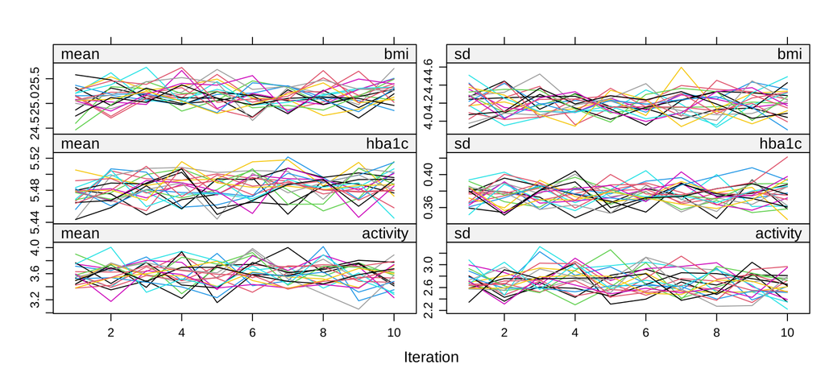

## Imputed vs observed values

```r
densityplot(imp, ~ bmi)
```

**Blue** = observed, **red** = imputed (each imputation). Imputed BMI is **shifted to the right** (mean 25.1 vs 24.1 observed): adults with a **high SBP**, who are more often missing, tend to have a **higher BMI**. Differences are **allowed** when the missingness is not random; **implausible values** are not.

## Imputed vs observed values

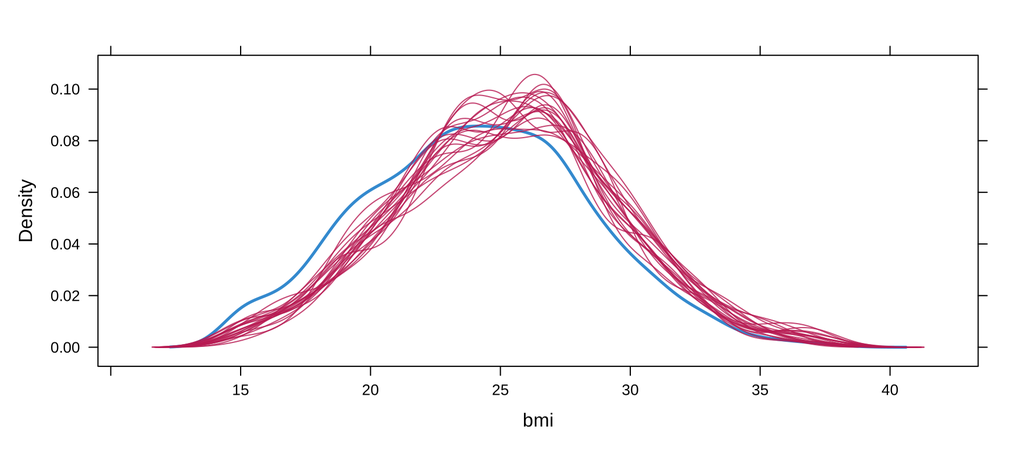

# Topic 3 — Analyse and pool

## with() and pool()

```r
fit <- with(imp, lm(sbp ~ age + sex + bmi + smoker + activity))
pooled <- pool(fit)
summary(pooled, conf.int = TRUE)[, c("term", "estimate", "std.error", "df", "conf.low", "conf.high")] |> mutate(across(where(is.numeric), \(x) round(x, 3)))
```

```
         term estimate std.error       df conf.low conf.high
1 (Intercept)   85.437     1.955  258.151   81.586    89.287
2         age    0.413     0.020 1234.023    0.374     0.452
3     sexMale    2.998     0.537  801.835    1.944     4.053
4         bmi    0.790     0.066  243.317    0.661     0.920
5   smokerYes    1.965     0.668  281.399    0.649     3.281
6    activity   -0.490     0.096  592.055   -0.679    -0.301
```

## Comparison with complete case

```r
m_cc <- lm(sbp ~ age + sex + bmi + smoker + activity, data = dat)
s <- summary(pooled, conf.int = TRUE)
round(rbind(complete_case = summary(m_cc)$coefficients["bmi", 1:2], multiple_imputation = unlist(s[s$term == "bmi", c("estimate", "std.error")])), 3)
```

```
                    Estimate Std. Error
complete_case          0.685      0.071
multiple_imputation    0.790      0.066
```

**MI 0.79 (SE 0.066)** against **complete case 0.69 (SE 0.071)**; the truth is about **0.80 to 0.86**. MI **removes most of the bias** and is **more precise** because it **uses all 2,000 adults**. The SE is **honest**: it includes the **between-imputation** variance.

## Rules for good imputation models

1. Include **all variables in the analysis model**, **including the outcome**
2. Include **auxiliary variables** that predict the missing values or the missingness
3. Include **interactions** and **non-linear terms** you will analyse (Session 4)
4. Use **enough imputations** (Session 4); set a **seed**
5. **Check** convergence and imputed values

## 🔧 Switch to R — Lab 3

**File:** `missing-workshop/labs/lab3_mice.R`

- default methods and predictor matrix
- `mice()` with 20 imputations, convergence, densities
- `with()` and `pool()`, comparison with complete case

**Time:** 40 minutes · answer the Q questions in the comments

## Self-check quiz (1/5)

What does predictive mean matching (pmm) do?

- It imputes the mean of the observed values in each imputed data set
- It predicts the missing value from a regression and uses the prediction as it is
- It matches adults with missing values to adults with the same pattern of missingness
- It imputes by borrowing an observed value from an adult with a similar prediction

## Self-check quiz (2/5)

Why are m imputed data sets created and analysed separately?

- To reflect the uncertainty about the missing values in the pooled SEs
- To obtain m independent estimates that are averaged without further steps
- Because each variable needs its own completed data set to be analysed
- To check that the results are identical across the m data sets of adults

## Self-check quiz (3/5)

What do Rubin’s rules do?

- They select the best imputed data set by the model fit statistics
- They average the imputed data sets before the model is fitted to them
- They average the estimates and add up two sources of variance
- They correct the p-values for the number of variables with missing data

## Self-check quiz (4/5)

In the convergence plot the lines of different imputations cross freely, with no trend. What does this suggest?

- The imputed values are the same in all of the data sets generated
- The iterations have mixed well, so it has probably converged
- The imputation model is correct and no other check is needed at all
- The number of iterations is too small and has to be increased

## Self-check quiz (5/5)

Why is the id column left out of the imputation model?

- mice cannot read character variables when they are stored in the data frame
- The id is nearly always strongly correlated with the outcome variable in the data
- A unique code carries no information, and as a predictor it adds noise
- Variables without missing values are not allowed in the imputation model

## Score and take-home

**Your score:**

- **Impute → analyse → pool** (`mice`, `with`, `pool`)
- **pmm** for continuous, **factors** for binary (`logreg`)
- Include the **outcome** and **auxiliary** variables; drop the **id**
- **Check**: convergence plot, density of imputed vs observed
- MI **0.79** vs complete-case **0.69** (truth about 0.80)

**Next:** Session 4: diagnostics, derived variables and the number of imputations